# HR Analytics: Recruitment & Engagement Insights

James Peters

2025-10-04

# HR Analytics project in R: Exploring Workforce Insights Through Data

Human Resources (HR) departments are increasingly expected to make **data-driven decisions** about how to attract, develop, and retain top talent. This case-based project demonstrates how **People Analytics** can be used to address real business questions using a synthetic HR dataset — all analyzed in **R**.

You’ll learn how to:

- Clean, manipulate, and visualize HR data using tidyverse tools.
- Apply **descriptive** and **inferential statistics** to uncover meaningful workforce patterns.
- Build **predictive models** (e.g., logistic and linear regression) to inform strategic decisions.

The analysis is organized into **five practical HR analytics scenarios**, each mirroring challenges analytics teams face in real organizations. For each, we use a combination of **summary statistics, hypothesis testing, and regression modeling** to arrive at actionable insights.

**1. Identifying the Best Recruiting Source**

Evaluate how different recruiting channels affect the **quality of hires**, **performance outcomes**, and **retention** rates.

- **Descriptive Statistics**: Performance and attrition by source
- **Statistical Tests**: ANOVA and Chi-square
- **Regression**: Logistic regression to predict attrition likelihood based on recruiting source

**2. Understanding Low Employee Engagement**

- **Business Question**: Is engagement in Sales statistically lower than in other departments? What factors contribute to disengagement?
- **Descriptive Exploration**: Vacation days, pay, performance, and tenure
- **Hypothesis Testing**:
  - Chi-square test for disengagement proportions
  - T-tests for vacation day differences
- **Regression**: Logistic regression to predict disengagement based on contributing factors

**3. Assessing Pay Equity for New Hires**

Explore whether new employees are being paid **equitably** compared to existing staff — and if these pay disparities affect **retention** or morale.

- **Statistical Tests**:
  - T-tests by gender, recruiting source, or department
- **Regression Modeling**:
  - Linear regression on salary as a function of gender, education, department, and experience

**4. Evaluating Consistency in Performance Ratings**

Are performance scores aligned with actual contributions — or influenced by **manager bias**, **department norms**, or **demographics**?

- **Descriptive Metrics**: Performance score distributions across departments
- **Statistical Tests**: ANOVA across teams
- **Regression**: Ordinal or logistic regression to analyze rating predictors

**5. Improving Workplace Safety Using Data**

Analyze trends in workplace incidents to guide **preventative safety interventions**.

- **Descriptive Statistics**: Incidents by department, time, and employee tenure
- **Statistical Tests**: Chi-square test for incident frequency across groups
- **Regression**: Logistic regression to predict likelihood of safety incidents

**Identifying the Best Recruiting Source**

Evaluate how different recruiting channels impact the quality of new hires and overall retention.

Import Dataset and load libraries

### References & Acknowledgments

This project builds upon concepts and datasets introduced in the following sources:

- **DataCamp** – *HR Analytics: Exploring Employee Data in R*  
  Course content and synthetic HR dataset structure were used as the foundation for analysis and exercises.  
  https://www.datacamp.com/
- **People Analytics: Using Data-Driven HR & Generative AI as a Business Advantage**  
  Provided strategic context and inspiration for connecting HR analytics to real business decision-making.

Additional HR analytics best practices were informed by public discussions on workforce analytics, people analytics, and HR data-driven decision-making trends.

## 1. Identify the best recruiting source

Import Dataset and load libraries

```r
library(readr)
library(dplyr)
```

```r
library(ggplot2)

# Load the readr package
recruitment <- read.csv("recruitment_data.csv")
```

Explore recruitment Data

```r
# Look at the first few rows of the dataset
head(recruitment)
```

```
##   attrition performance_rating sales_quota_pct recruiting_source
## 1       Yes                  1           0.494         Referral
## 2        No                  5           0.883    Applied Online
## 3        No                  3           1.302    Applied Online
## 4        No                  3           2.140         Referral
## 5       Yes                  4           1.560         Referral
## 6       Yes                  3           2.074    Applied Online
```

```r
# Look at the last few rows of the dataset
tail(recruitment)
```

```
##     attrition performance_rating sales_quota_pct recruiting_source
## 495        No                  4           1.594       Search Firm
## 496       Yes                  3           0.707               N/A
## 497        No                  1           0.398    Applied Online
## 498        No                  1           1.587       Search Firm
## 499        No                  3           1.421            Campus
## 500       Yes                  2           0.484       Search Firm
```

view

```r
View(recruitment)
```

Summary

```r
# Get an overview of the recruitment data
summary(recruitment)
```

```
##   attrition         performance_rating sales_quota_pct  recruiting_source
##  Length:500         Min.   :1.000      Min.   :0.3010   Length:500
##  Class :character   1st Qu.:2.000      1st Qu.:0.8495   Class :character
##  Mode  :character   Median :3.000      Median :1.4100   Mode  :character
##                     Mean   :2.898      Mean   :1.3808
##                     3rd Qu.:4.000      3rd Qu.:1.9053
##                     Max.   :5.000      Max.   :2.4910
```

Structure

```r
str(recruitment)
```

```
## 'data.frame':    500 obs. of  4 variables:
##  $ attrition         : chr  "Yes" "No" "No" "No" ...
##  $ performance_rating: int  1 5 3 3 4 3 1 1 4 2 ...
##  $ sales_quota_pct   : num  0.494 0.883 1.302 2.14 1.56 ...
##  $ recruiting_source : chr  "Referral " "Applied Online" "Applied Online" "Referral " ...
```

dim

```r
dim(recruitment)
```

```
## [1] 500   4
```

col names

```r
colnames(recruitment)
```

```
## [1] "attrition"          "performance_rating" "sales_quota_pct"
## [4] "recruiting_source"
```

gliimpse

```r
glimpse(recruitment)
```

```
## Rows: 500
## Columns: 4
## $ attrition          <chr> "Yes", "No", "No", "No", "Yes", "Yes", "No", "No", …
## $ performance_rating <int> 1, 5, 3, 3, 4, 3, 1, 1, 4, 2, 3, 1, 5, 4, 3, 2, 5, …
## $ sales_quota_pct    <dbl> 0.494, 0.883, 1.302, 2.140, 1.560, 2.074, 0.608, 1.…
## $ recruiting_source  <chr> "Referral ", "Applied Online", "Applied Online", "R…
```

Missing values

```r
anyNA(recruitment)
```

```
## [1] FALSE
```

# Identifying the Best Recruiting Source

- Recruitment channels can differ widely in cost, candidate quality, and long-term retention.
- Analyzing these channels helps HR invest in the sources that yield **high-performing and long-tenured employees**, reducing turnover costs.

## Identify the recruiting source

```r
recruit <-  recruitment |>  count(recruiting_source)
recruit
```

```
##   recruiting_source   n
## 1    Applied Online 111
## 2            Campus  81
## 3               N/A 101
## 4         Referral   99
## 5       Search Firm 108
```

## visualize recruiting sources

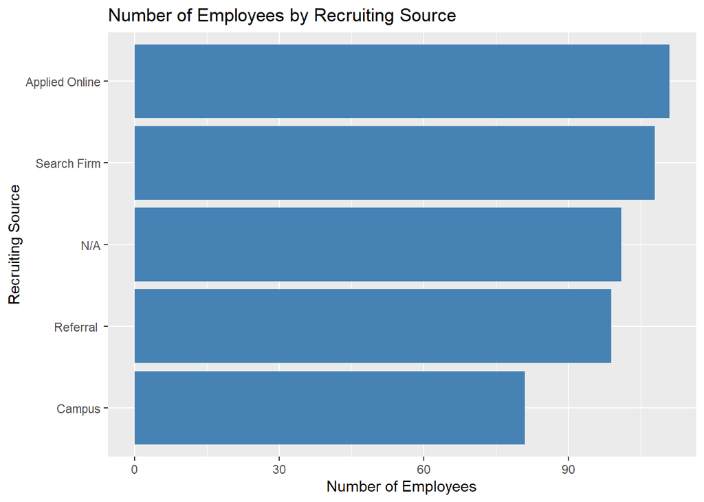

```r
ggplot(recruit, aes(x = reorder(recruiting_source, n), y = n)) + geom_col(fill = "steelblue") + coord_flip() + labs( title = "Number of Employees by Recruiting Source",  x = "Recruiting Source", y = "Number of Employees")
```

# Which recruiting channel produces the best and worst salespeople?

## Avg sales numbers by recruiting source

```
Find the average sales quota attainment by recruiting source
```

```r
# Find the average sales quota attainment for each recruiting source.
avg_sales <- recruitment |> group_by(recruiting_source) |> summarize(avg_sales_quota_pct = mean(sales_quota_pct))

# Display the result
avg_sales
```

```
## # A tibble: 5 × 2
##   recruiting_source avg_sales_quota_pct
##   <chr>                           <dbl>
## 1 "Applied Online"                 1.39
## 2 "Campus"                         1.30
## 3 "N/A"                            1.43
## 4 "Referral "                      1.37
## 5 "Search Firm"                    1.39
```

Visualizing avg sale numbers by recruiting source

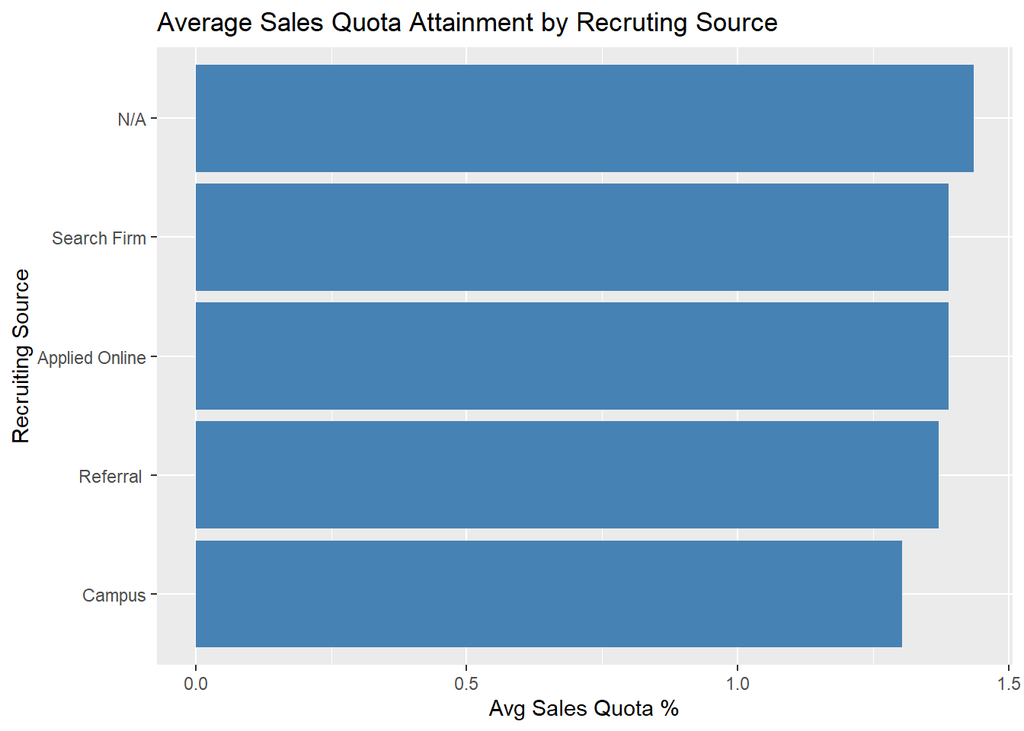

```r
ggplot(avg_sales, aes(x = reorder(recruiting_source, avg_sales_quota_pct),
                      y = avg_sales_quota_pct)) + geom_col(fill = "steelblue") + coord_flip() + labs( title = "Average Sales Quota Attainment by Recruting Source", x = "Recruiting Source",  y = "Avg Sales Quota %" )
```

* Which recruiting channel produces the highest and lowest Attrition rates?

# Attrition rates by recruiting source

## Find the average attrition for the Sales team, by recruiting source, sorted from lowest attrition rate to highest

```r
avg_attrition <- recruitment |>
  group_by(recruiting_source) |>
  summarize(attrition_rate = mean(ifelse(attrition == "Yes", 1, 0), na.rm = TRUE)) |> arrange(attrition_rate)
# Display the result
avg_attrition
```

```
## # A tibble: 5 × 2
##   recruiting_source attrition_rate
##   <chr>                      <dbl>
## 1 "Referral "                0.444
## 2 "N/A"                      0.465
## 3 "Campus"                   0.494
## 4 "Search Firm"              0.528
## 5 "Applied Online"           0.559
```

# Visualizing attrition rates by recruiting sources

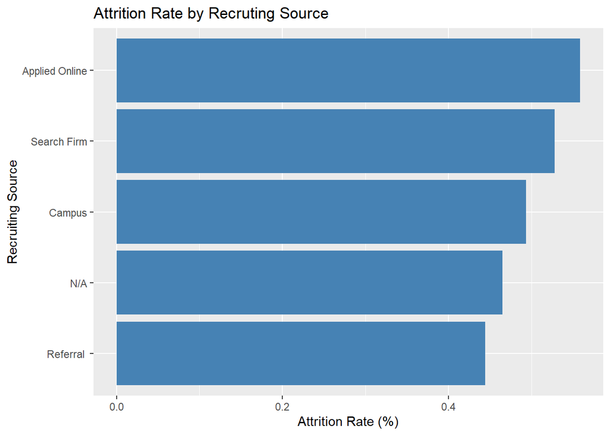

```r
ggplot(avg_attrition, aes(x = reorder(recruiting_source, attrition_rate),
                          y = attrition_rate)) + geom_col(fill = "steelblue") + coord_flip() + labs( title = "Attrition Rate by Recruting Source",
                                                                                                     x = "Recruiting Source", y = "Attrition Rate (%)")
```

## Which recruiting source produce the highest and lowest Performance rates

```r
avg_performance <- recruitment |>
  group_by(recruiting_source) |>
  summarize(performance_rate = mean(performance_rating, na.rm = TRUE)) |>
  arrange(desc(performance_rate))

# View result
avg_performance
```

```
## # A tibble: 5 × 2
##   recruiting_source performance_rate
##   <chr>                        <dbl>
## 1 "Campus"                      3.06
## 2 "N/A"                         2.91
## 3 "Applied Online"              2.90
## 4 "Referral "                   2.90
## 5 "Search Firm"                 2.76
```

## visualize performance

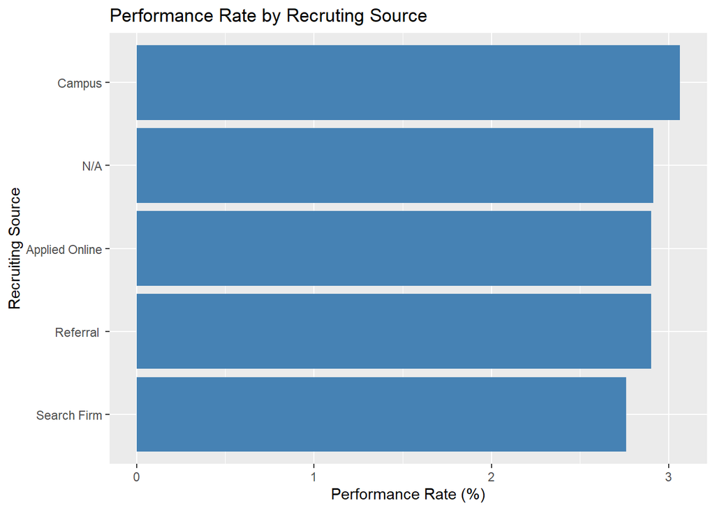

```r
ggplot(avg_performance, aes(x = reorder(recruiting_source, performance_rate),
                            y = performance_rate)) + geom_col(fill = "steelblue") + coord_flip() + labs( title = "Performance Rate by Recruting Source", x = "Recruiting Source", y = "Performance Rate (%)")
```

## Statistical test

- **Chi-Square Test:**  
  Tests whether attrition (Yes/No) is **independent** of recruiting source, revealing if some sources lead to higher turnover.

Chi-Square Test – Attrition vs Recruiting Source * Checks whether attrition status (Yes/No) is independent of recruiting source.

```r
# Create a contingency table
tab <- table(recruitment$recruiting_source, recruitment$attrition)

# View the table
tab
```

```
##
##                  No Yes
##   Applied Online 49  62
##   Campus         41  40
##   N/A            54  47
##   Referral       55  44
##   Search Firm    51  57
```

```r
# Perform Chi-Square test
chisq.test(tab)
```

```
##
##  Pearson's Chi-squared test
##
## data:  tab
## X-squared = 3.5756, df = 4, p-value = 0.4665
```

Interpretation:

We fail to reject the null hypothesis; attrition appears independent of recruiting source in this dataset. The observed attrition differences across Applied Online, Campus, N/A, Referral, and Search Firm could be due to random variation.

### Regression Modeling

- **Logistic Regression:**  
  Predicts the probability of attrition (1 = left, 0 = stayed) using recruiting source as a predictor, possibly controlling for tenure, department, or salary.

### Logistic Regression – Predict Attrition Likelihood

- Models the probability of attrition (Yes=1, No=0) from source + other available metrics.

```r
# Ensure attrition is coded as a binary factor
recruitment$attrition <- factor(recruitment$attrition, levels = c("No", "Yes"))

# Fit logistic regression
logit_model <- glm(attrition ~ recruiting_source + performance_rating + sales_quota_pct,
                   data = recruitment,
                   family = binomial)

summary(logit_model)
```

```
##
## Call:
## glm(formula = attrition ~ recruiting_source + performance_rating +
##     sales_quota_pct, family = binomial, data = recruitment)
##
## Coefficients:
##                              Estimate Std. Error z value Pr(>|z|)
## (Intercept)                   0.81149    0.34412   2.358   0.0184 *
## recruiting_sourceCampus      -0.27448    0.29478  -0.931   0.3518
## recruiting_sourceN/A         -0.36505    0.27761  -1.315   0.1885
## recruiting_sourceReferral    -0.46789    0.27967  -1.673   0.0943 .
## recruiting_sourceSearch Firm -0.13557    0.27293  -0.497   0.6194
## performance_rating           -0.07006    0.06293  -1.113   0.2656
## sales_quota_pct              -0.26665    0.14650  -1.820   0.0687 .
## ---
## Signif. codes:  0 '***' 0.001 '**' 0.01 '*' 0.05 '.' 0.1 ' ' 1
##
## (Dispersion parameter for binomial family taken to be 1)
##
##     Null deviance: 693.15  on 499  degrees of freedom
## Residual deviance: 685.24  on 493  degrees of freedom
## AIC: 699.24
##
## Number of Fisher Scoring iterations: 4
```

In this dataset, recruiting source does not significantly predict attrition. Referral hires trend toward lower attrition (OR ≈ 0.63) but not at a strong significance level (p=0.09). Higher sales quota attainment shows a mild trend toward lower attrition (OR ≈ 0.77, p=0.07), but the effect is not clearly significant. Overall, the model suggests no strong predictors of attrition among these variables alone — additional features such as tenure, department, and salary would likely improve predictive accuracy.

2. Understanding Low Employee Engagement

# Import Suvey data

```r
survey <- read.csv("survey_data.csv")
head(survey)
```

```
##   employee_id  department engagement salary vacation Vacation_days_taken
## 1           1 Engineering          4  75100       18                   6
## 2           2 Engineering          2  84800       18                   1
## 3           3   Marketing          4  61500       20                  15
## 4           4       Sales          5  62500       25                   1
## 5           5       Sales          3  64400       13                  27
## 6           6 Engineering          4  97900       26                  24
```

```r
tail(survey)
```

```
##      employee_id department engagement salary vacation Vacation_days_taken
## 2995        2995    Finance          2  64700       11                  18
## 2996        2996  Marketing          4  90200       17                   0
## 2997        2997         HR          4  32800       15                  12
## 2998        2998         IT          1  71300       12                  16
## 2999        2999    Finance          1  86000       29                   1
## 3000        3000  Marketing          3  49900       26                   6
```

view

```r
View(survey)
```

Summary

```r
# Get an overview of the recruitment data
summary(survey)
```

```
##   employee_id      department          engagement        salary
##  Min.   :   1.0   Length:3000        Min.   :1.000   Min.   : 18200
##  1st Qu.: 750.8   Class :character   1st Qu.:2.000   1st Qu.: 59775
##  Median :1500.5   Mode  :character   Median :3.000   Median : 69700
##  Mean   :1500.5                      Mean   :2.998   Mean   : 69778
##  3rd Qu.:2250.2                      3rd Qu.:4.000   3rd Qu.: 80100
##  Max.   :3000.0                      Max.   :5.000   Max.   :121200
##     vacation     Vacation_days_taken
##  Min.   :10.00   Min.   : 0.00
##  1st Qu.:15.00   1st Qu.: 7.75
##  Median :20.00   Median :15.00
##  Mean   :20.22   Mean   :15.09
##  3rd Qu.:26.00   3rd Qu.:22.00
##  Max.   :30.00   Max.   :30.00
```

Structure

```r
str(survey)
```

```
## 'data.frame':    3000 obs. of  6 variables:
##  $ employee_id        : int  1 2 3 4 5 6 7 8 9 10 ...
##  $ department         : chr  "Engineering" "Engineering" "Marketing" "Sales" ...
##  $ engagement         : int  4 2 4 5 3 4 3 1 1 4 ...
##  $ salary             : num  75100 84800 61500 62500 64400 ...
##  $ vacation           : int  18 18 20 25 13 26 11 29 24 28 ...
##  $ Vacation_days_taken: int  6 1 15 1 27 24 7 5 18 4 ...
```

dim

```r
dim(survey)
```

```
## [1] 3000    6
```

col names

```r
colnames(survey)
```

```
## [1] "employee_id"         "department"          "engagement"
## [4] "salary"              "vacation"            "Vacation_days_taken"
```

gliimpse

```r
glimpse(survey)
```

```
## Rows: 3,000
## Columns: 6
## $ employee_id         <int> 1, 2, 3, 4, 5, 6, 7, 8, 9, 10, 11, 12, 13, 14, 15,…
## $ department          <chr> "Engineering", "Engineering", "Marketing", "Sales"…
## $ engagement          <int> 4, 2, 4, 5, 3, 4, 3, 1, 1, 4, 2, 5, 5, 5, 1, 4, 2,…
## $ salary              <dbl> 75100, 84800, 61500, 62500, 64400, 97900, 102300, …
## $ vacation            <int> 18, 18, 20, 25, 13, 26, 11, 29, 24, 28, 23, 10, 17…
## $ Vacation_days_taken <int> 6, 1, 15, 1, 27, 24, 7, 5, 18, 4, 6, 15, 25, 10, 3…
```

Missing values

```r
anyNA(survey)
```

```
## [1] FALSE
```

# # **Which department has the lowest engagement?** What factors contribute to disengagement?

## Examine the counts of the department variable.

```r
sur1 <- survey %>%
  count(department)
sur1
```

```
##    department   n
## 1 Engineering 436
## 2     Finance 394
## 3          HR 429
## 4          IT 444
## 5   Marketing 409
## 6  Operations 430
## 7       Sales 458
```

visualize

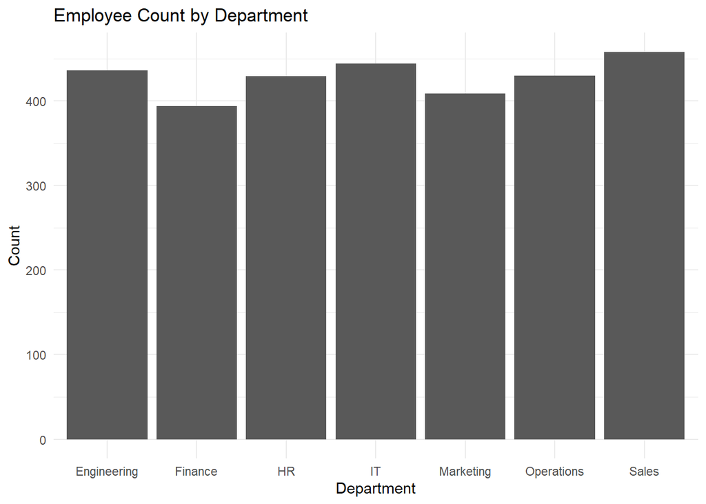

```r
ggplot(sur1, aes(x = department, y = n)) +
  geom_col() +
  labs(title = "Employee Count by Department",
       x = "Department", y = "Count") +
  theme_minimal()
```

INterpretation: Sales highest and Finance lowest.

```r
# Output the average engagement score for each department, sorted
survey %>%
  group_by(department) %>%
  summarize(avg_engagement = mean(engagement)) %>%
  arrange(avg_engagement)
```

```
## # A tibble: 7 × 2
##   department  avg_engagement
##   <chr>                <dbl>
## 1 IT                    2.95
## 2 Operations            2.96
## 3 Marketing             2.97
## 4 Sales                 3.00
## 5 HR                    3.01
## 6 Finance               3.03
## 7 Engineering           3.08
```

Interpretation: Department with the lowest engagement score. “IT”

## **Comparing other factors by department**

Another common way to think about engagement is identifying which employees are *disengaged*, which you’ll define as having an engagement score of 1 or 2.

```r
# Create the disengaged variable and assign the result to survey
survey_disengaged <- survey %>%
  mutate(disengaged = ifelse(engagement <= 2, 1, 0))

survey_disengaged
```

[output not shown]

[output cut: 5987 more lines]

## Summarize the three variables by department

```r
survey_summary <- survey_disengaged %>%
  group_by(department) %>%
  summarize(pct_disengaged = mean(disengaged),
            avg_salary = mean(salary),
            avg_vacation_days = mean(Vacation_days_taken))

survey_summary
```

```
## # A tibble: 7 × 4
##   department  pct_disengaged avg_salary avg_vacation_days
##   <chr>                <dbl>      <dbl>             <dbl>
## 1 Engineering          0.376     69723.              15.2
## 2 Finance              0.401     69470.              15.2
## 3 HR                   0.406     68632.              15.7
## 4 IT                   0.414     70662.              14.9
## 5 Marketing            0.413     69814.              14.3
## 6 Operations           0.414     69834.              15.3
## 7 Sales                0.415     70228.              15.0
```